# Final Project

Vince Birch & Stephen Polacheck 2

Due: May 1

# Front matter

```r
# always clean up R environment
rm(list = ls())
# load all packages here
library(mdsr)
library(tidyverse)
library(lubridate)
library(mosaic)
library(Hmisc)
library(dplyr)
library(Lahman)
library(rvest)
library(methods)
library(readr)
library(rpart)
library(ROCR)
library(NHANES)
library(tidyr)
library(DataComputing)
library(mosaicData)
library(tidyverse)
library(party)
library(tidyr)
library(modelr)
# user defined functions
# aggwpct - takes in a data set, calculates the winning percentage for each variable(if given).
# simple_sim - runs a simulation on a uniform distribution
```

# Loading Data

```r
CitiesPopulationRaw <-
  read.csv(file = "CitiesPopulation.csv", header = TRUE, sep = ",")
CitiesEconomyRaw <-
  read.csv(file = "CitiesEconomy.csv", header = TRUE, sep = ",")
CitiesIncomeDistributionRaw <-
  read.csv(file = "CitiesIncomeDistribution.csv", header = TRUE, sep = ",")
CitiesEnvironmentRaw <-
  read.csv(file = "CitiesEnvironment.csv", header = TRUE, sep = ",")
HappyCitiesRaw <-
  read.csv(file = "HappyCities.csv", header = TRUE, sep = ",")
NFLTeamDataRaw <-
  read.csv(file = "NFL Team Data.csv", header = TRUE, sep = ",")
MLBTeamDataRaw <-
  read.csv(file = "MLBWinning.csv", header = TRUE, sep = ",")
NHLTeamDataRaw <-
  read.csv(file = "NHL Data.csv", header = TRUE, sep = ",")
NBATeamDataRaw <-
  read.csv(file = "NBAData.csv", header = TRUE, sep = ",")
```

# Data wrangling

Here below, we edited the Cities Population data in case we needed it later. We downloaded the CSV and included it in the folder as CitiesPopulationRaw. We renamed certain variables we needed, and selected only amounts that measured the number of people in each city. This was to prevent us from collecting data about events, such as population density. Then, we only suggested the years, city names, countries, and values (population).

```r
colnames(CitiesPopulationRaw)[1] <- "Country_Code"
colnames(CitiesPopulationRaw)[2] <- "City_Name"
CitiesPopulation <-
  CitiesPopulationRaw %>%
  filter(Unit.Code == "PER") %>%
  filter(Unit == "Persons") %>%
  filter(VAR == "T_T") %>%
  select(Year, City_Name, Country_Code, Value)
colnames(CitiesPopulation)[4] <- "Population"
```

Next, we edited more data we found from online. This one was about the economies of different cities in different years. We went through and renamed the columns into variables we could recognize, then selected only real GDP for values.

```r
colnames(CitiesEconomyRaw)[1] <- "Country_Code"
colnames(CitiesEconomyRaw)[2] <- "City_Name"
CitiesEconomy <-
  CitiesEconomyRaw %>%
  filter(VAR == "GDP_REAL_PPP") %>%
  select(Year, City_Name, Country_Code, Value)
colnames(CitiesEconomy)[4] <- "GDP"
```

We did a similar task, except with disposable income. For this, we found the disposable income per equivalised household in USD for our base value, and performed similar operations to previous data sets to clean it.

```r
colnames(CitiesIncomeDistributionRaw)[1] <- "Country_Code"
colnames(CitiesIncomeDistributionRaw)[2] <- "City_Name"
CitiesIncomeDistribution <-
  CitiesIncomeDistributionRaw %>%
  filter(VAR == "INCOME_DISP_HH_REAL_PPP") %>%
  select(Year, City_Name, Country_Code, Value)
colnames(CitiesIncomeDistribution)[4] <- "IncomeDistribution"
```

We did some more data cleaning and cleaned air pollution levels for each city (share of inhabitants exposed to particles). We used a similar method from above.

```r
colnames(CitiesEnvironmentRaw)[1] <- "Country_Code"
colnames(CitiesEnvironmentRaw)[2] <- "City_Name"
CitiesEnvironment <-
  CitiesEnvironmentRaw %>%
  select(Year, City_Name, Country_Code, Value)
colnames(CitiesEnvironment)[4] <- "SPEX_10"
```

Finally, we included our happiness ranks for each city. Once again, this data was taken from a website, and also includes total score, emotional/physical/wellbeing rank, income/employment rank, and community/environment rank. We mainly focused on the total score in our analysis.

```r
colnames(HappyCitiesRaw)[1] <- "Rank"
colnames(HappyCitiesRaw)[2] <- "City"
colnames(HappyCitiesRaw)[3] <- "Total_Score"
colnames(HappyCitiesRaw)[4] <- "Emotional_Physical_WellBeing_Rank"
colnames(HappyCitiesRaw)[5] <- "Income_Employment_rank"
colnames(HappyCitiesRaw)[6] <- "Community_Environment_Rank"
HappyCities <-
  HappyCitiesRaw %>%
  select(-Rank)
```

Next, we took care of some NFL data. I went through and named all of the columns, and then created a column with win percent. Through this, I also used a gsub to take different symbols out of the teams names. Finally, I filtered the year to be after 2000, as I didn’t think old NFL data would effect cities’s happiness today too much.

```r
colnames(NFLTeamDataRaw)[1] <- "Year"
colnames(NFLTeamDataRaw)[3] <- "Team"
colnames(NFLTeamDataRaw)[4] <- "City"
colnames(NFLTeamDataRaw)[5] <- "Wins"
colnames(NFLTeamDataRaw)[6] <- "Losses"
colnames(NFLTeamDataRaw)[7] <- "Ties"
NFLTeamData <-
  NFLTeamDataRaw %>%
  select(Year, City, Team, Wins, Losses, Ties) %>%
  mutate(Year = as.numeric(Year),
         Team = gsub("[*|+]","", Team),
         Wins = as.numeric(Wins),
         Losses = as.numeric(Losses),
         Ties = as.numeric(Ties),
         Win_Percent = Wins / (Wins + Losses + Ties)) %>%
  filter(Year >= 2000)  %>%
  mutate(League = "NFL") %>%
  select(Year, City, Win_Percent, League)
```

The MLB data was formatted differently, having already computed the win percentages. I then just selected the rows, and edited it later in the document.

```r
MLBTeamWinningPercentage <-
  MLBTeamDataRaw %>%
  select(X, X2018, X2017, X2016, X2015, X2014, X2013, X2012, X2011, X2010,
         X2009, X2008, X2007, X2006, X2005, X2004, X2003, X2002, X2001, X2000) %>%
  mutate(League = "MLB")
colnames(MLBTeamWinningPercentage)[1] <- "Teams"
```

To edit the MLB team data, we went through and removed the x before each year, and GATHERed together the years win percentages to get a teams column, year column, and Win Percentage column. Then, we just formatted the data so it was in the same form as the NFL data.

```r
MLBTeamWinningPercentage2 <-
MLBTeamWinningPercentage %>%
gather("year", "WPCT", 2:21) %>%
mutate(year = gsub("X", "",year)) %>%
  mutate(league = "MLB",
         WPCT = as.numeric(WPCT),
         year = as.numeric(year)) %>%
  mutate(City = Teams)
```

```
NAs introduced by coercionNAs introduced by coercion
```

The NBA data was almost identical to how we wanted to it. While we selected certain rows and added a league column, we largely left this one alone.

```r
NBATeamWinningPercentage <-
  NBATeamDataRaw %>%
  select(Year, City, WPCT) %>%
  mutate(League = "NBA",
         WPCT = as.numeric(WPCT))
```

The NHL data was very similar to the NBA data. We had to do very little work on it.

```r
NHLTeamWinningPercentage <-
  NHLTeamDataRaw %>%
  mutate(League = "NHL") %>%
  select(Year, City, WPCT, League)
```

Then, we edited the CitiesPopulation data to remove all of the extra spaces, parentheses, and changed come of the combined cities into one city. Along with this, it only selected cities that are in the United States. In this, we used a gsub after viewing the Tampa data to make it turn ‘Tampa-Hillsborough’ and ‘Tampa-Pinellas’ into Tampa.

```r
USACitiesPopulation <-
  CitiesPopulation %>%
  filter(grepl("^USA", Country_Code) == TRUE) %>%
  mutate(City_Name = gsub(' \\(.*\\)', "", City_Name),
         City_Name = gsub('Tampa-Hillsborough', "Tampa", City_Name),
         City_Name = gsub('Tampa-Pinellas', "Tampa", City_Name),
         Population = as.numeric(Population))
```

We did the exact same procedure on the CitiesEconomy data and found all of the United States city GDP data.

```r
USACitiesEconomy <-
  CitiesEconomy %>%
  filter(grepl("^USA", Country_Code) == TRUE) %>%
  mutate(City_Name = gsub('\\(.*\\)', "", City_Name),
         City_Name = gsub('Tampa-Hillsborough', "Tampa", City_Name),
         City_Name = gsub('Tampa-Pinellas', "Tampa", City_Name))
```

We completed the same process and edited the income distribution data for United States cities.

```r
USACitiesIncomeDistribution <-
  CitiesIncomeDistribution %>%
  filter(grepl("^USA", Country_Code) == TRUE) %>%
  mutate(City_Name = gsub('\\(.*\\)', "", City_Name),
         City_Name = gsub('Tampa-Hillsborough', "Tampa", City_Name),
         City_Name = gsub('Tampa-Pinellas', "Tampa", City_Name))
```

We used the same process to edit the CityEnvironment data to only select US cities.

```r
USACitiesEnvironment <-
  CitiesEnvironment %>%
  filter(grepl("^USA", Country_Code) == TRUE)
USACitiesEnvironment <-
  USACitiesEnvironment %>%
  mutate(City_Name = gsub('\\(.*\\)', "", City_Name),
         City_Name = gsub('Tampa-Hillsborough', "Tampa", City_Name),
         City_Name = gsub('Tampa-Pinellas', "Tampa", City_Name))
```

We did the same then with the happiness data, and it just required an extra gsub to clean it to match the rest of our data.

```r
HappyCities <-
  HappyCities %>%
  mutate(City = gsub(", ..", "", City),
       Year = 2018)
```

In the next chunk of data, we joined together each of the NFL, MLB, NBA, and NHL data sets. We did this by going through one at a time and adding it with a full join. A full join workekd best for us, as we did want blanks if the teams did not have all sports teams combined. We did it for each table by year and city, as we can see the winning percentage for a team in each league in each city each year. One interesting thing we did notice was that NY and LA had all possible combinations for their teams, instead of just 2 selections. We decided to leave this, as it could show the different loyalties within a city.

```r
NFLandMLB <-
MLBTeamWinningPercentage2 %>%
  full_join(NFLTeamData, by = c("Teams" = "City", "year" = "Year"))
```

```
Column `Teams`/`City` joining factors with different levels, coercing to character vector
```

```r
AddingNBA <-
NFLandMLB %>%
 full_join(NBATeamWinningPercentage, by = c("City" = "City", "year" = "Year"))
```

```
Column `City` joining factors with different levels, coercing to character vector
```

```r
AddingNHL <-
AddingNBA %>%
 full_join(NHLTeamWinningPercentage, by = c("City" = "City", "year" = "Year"))
```

```
Column `City` joining character vector and factor, coercing into character vector
```

```r
AddingNHL %>%
  head()
```

|  | Teams | year | WPCT.x | league | City | Win_Percent | League.x | WPCT.y | League.y | WPCT | League |
| --- | --- | --- | --- | --- | --- | --- | --- | --- | --- | --- | --- |
| 1 | Phoenix | 2018 | 0.503 | MLB | Phoenix | 0.1875 | NFL | 0.232 | NBA | 0.4268293 | NHL |
| 2 | Atlanta | 2018 | 0.552 | MLB | Atlanta | 0.4375 | NFL | 0.354 | NBA | NA | NA |
| 3 | Baltimore | 2018 | 0.288 | MLB | Baltimore | 0.6250 | NFL | NA | NA | NA | NA |
| 4 | Boston | 2018 | 0.663 | MLB | Boston | 0.6875 | NFL | 0.598 | NBA | 0.6829268 | NHL |
| 5 | Chicago | 2018 | 0.583 | MLB | Chicago | 0.7500 | NFL | 0.268 | NBA | 0.4634146 | NHL |
| 6 | Chicago | 2018 | 0.380 | MLB | Chicago | 0.7500 | NFL | 0.268 | NBA | 0.4634146 | NHL |

We used a similar process to add population to the list. This was done using a left_join so we combined population with any team that ever had any sports team. We could have done a full join, but it would have made our data table absolutely massive, and we weren’t really intending on using that either.

```r
PlusPopulation <-
  AddingNHL %>%
 left_join(USACitiesPopulation, by = c("City" = "City_Name", "year" = "Year")) %>%
  select(-Country_Code)
```

Finally, similarly to the population code, we added in the happiness ratings for cities in 2018. Once again, we used a left join so we don’t have too many blank cells.

```r
PlusHappy <-
  PlusPopulation %>%
 left_join(HappyCities, by = c("City" = "City"))
```

Next, we wanted to write a function that went through the data and calculated the aggregate winning percentage fore each city. We did this, by writing a function that looked at the four winning percentages, then determined if it was NA or not. If it was not NA, the count went up and we included the percentage in the total. If it was NA, it was not included.

```r
aggwpct <- function(data){
  count = 0
  winpercent = 0
  wp1 = as.numeric(data[3])
  wp2 = as.numeric(data[6])
  wp3 = as.numeric(data[8])
  wp4 = as.numeric(data[10])
  if(is.na(wp1) == FALSE){
    winpercent = winpercent + wp1
    count = count + 1
    }
  if(is.na(wp2) == FALSE){
    winpercent = winpercent + wp2
    count = count + 1
    }
  if(is.na(wp3) == FALSE){
    winpercent = winpercent + wp3
    count = count + 1
    }
  if(is.na(wp4) == FALSE){
    winpercent = winpercent + wp4
    count = count + 1
    }
  winpercent = winpercent / count
return(winpercent)
}
```

Then, we applied that function we just wrote to our PlusHappy data. First we checked it to make sure all of the winning percentages were numeric, and then used an apply function to do it to each row of our data set. We put this in a a variable in PlusHappy called Total_WinPercent

```r
PlusHappy <-
  PlusHappy %>%
  mutate(WPCT_x = as.numeric(WPCT.x),
         Win_Percent = as.numeric(Win_Percent),
         WPCT_y = as.numeric(WPCT.y),
         WPCT = as.numeric(WPCT))
PlusHappy <-
  PlusHappy %>%
  mutate(Total_WinPercent = apply(PlusHappy, 1, aggwpct))
PlusHappy %>%
  head()
```

|  | Teams | year | WPCT.x | league | City | Win_Percent | League.x | WPCT.y | League.y | WPCT | League | Population | Total_Score | Emotional_Physical_WellBeing_Rank | Income_Employment_rank | Community_Environment_Rank | Year | WPCT_x | WPCT_y | Total_WinPercent |
| --- | --- | --- | --- | --- | --- | --- | --- | --- | --- | --- | --- | --- | --- | --- | --- | --- | --- | --- | --- | --- |
| 1 | Phoenix | 2018 | 0.503 | MLB | Phoenix | 0.1875 | NFL | 0.232 | NBA | 0.4268293 | NHL | NA | 51.94 | 87 | 136 | 172 | 2018 | 0.503 | 0.232 | 0.3373323 |
| 2 | Atlanta | 2018 | 0.552 | MLB | Atlanta | 0.4375 | NFL | 0.354 | NBA | NA | NA | NA | 58.46 | 64 | 88 | 100 | 2018 | 0.552 | 0.354 | 0.4478333 |
| 3 | Baltimore | 2018 | 0.288 | MLB | Baltimore | 0.6250 | NFL | NA | NA | NA | NA | NA | 44.75 | 148 | 161 | 177 | 2018 | 0.288 | NA | 0.4565000 |
| 4 | Boston | 2018 | 0.663 | MLB | Boston | 0.6875 | NFL | 0.598 | NBA | 0.6829268 | NHL | NA | 60.96 | 34 | 12 | 152 | 2018 | 0.663 | 0.598 | 0.6578567 |
| 5 | Chicago | 2018 | 0.583 | MLB | Chicago | 0.7500 | NFL | 0.268 | NBA | 0.4634146 | NHL | NA | 55.20 | 60 | 175 | 114 | 2018 | 0.583 | 0.268 | 0.5161037 |
| 6 | Chicago | 2018 | 0.380 | MLB | Chicago | 0.7500 | NFL | 0.268 | NBA | 0.4634146 | NHL | NA | 55.20 | 60 | 175 | 114 | 2018 | 0.380 | 0.268 | 0.4653536 |

Next, we used the data to create a graph that showed the relationshp between total winning percentage on the x axis and happiness score on the y-axis. Then, the color was NFL winning percentage. We noticed after looking at the graph the myriad of LA and NYC teams formed most of the large groups of straight lines. We thought there was a chance the total win percentage and happiness could be related, but if you removed Detroit (point at the very bottom), the ‘relationship’ was a lot less clear. We decided to investigate the NFL data compared to the happiness data question more. The color represnts the NFL team’s win percent.

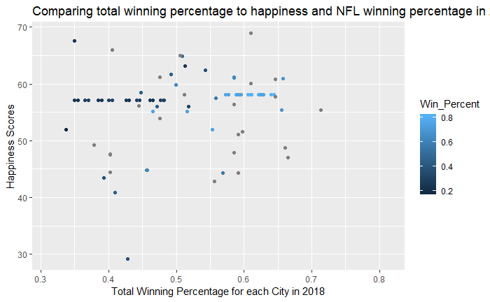

```r
PlusHappy %>%
  filter(year == 2018) %>%
ggplot(aes(x = Total_WinPercent, y = Total_Score, color = Win_Percent)) +
  geom_point() +
  ggtitle("Comparing total winning percentage to happiness and NFL winning percentage in 2018") +
  geom_jitter() +
  xlab("Total Winning Percentage for each City in 2018") +
  ylab("Happiness Scores")
```

Next, we created happiness data only using the NFL and Happiness data - just to remove all the extraneous info for some further analysis. We weren’t sure if the following data provided us with any insight how NFL winning percentage affected happiness.

```r
NFLHappiness <-
  NFLTeamData %>%
 left_join(HappyCities, by = c("City" = "City"))
```

```
Column `City` joining factor and character vector, coercing into character vector
```

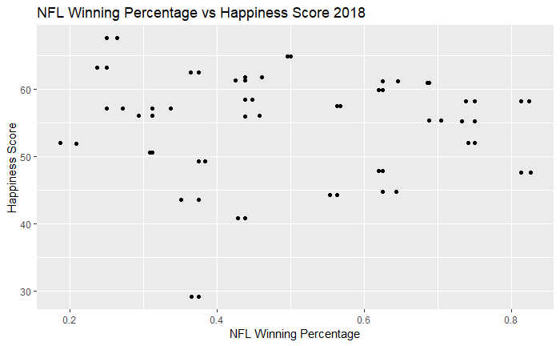

```r
NFLHappiness %>%
  filter(Year.x == 2018) %>%
ggplot(aes(x = Win_Percent, y = Total_Score)) +
  geom_point() +
  geom_jitter() +
  xlab("NFL Winning Percentage") +
  ylab("Happiness Score") +
  ggtitle("NFL Winning Percentage vs Happiness Score 2018")
```

```r
set.seed(50)
NFLHappiness2 <-
  NFLHappiness %>%
  filter(Year.x == 2018)
NFLHappiness15 <-
  NFLHappiness %>%
  sample_n(size = 15)
```

Next, we looked at the data to see the distribution of where the winning percentages fell.

```r
favstats( ~ Win_Percent, data = NFLHappiness15)
```

|  | min | Q1 | median | Q3 | max | mean | sd | n | missing |
| --- | --- | --- | --- | --- | --- | --- | --- | --- | --- |
|  | 0.3125 | 0.40625 | 0.5625 | 0.65625 | 0.875 | 0.5666667 | 0.171109 | 15 | 0 |

Then, we looked at the 62.5 percentile, as that is the usual mark for a team to make playoffs.

```r
Playoffs15 <- qdata(~ Win_Percent, p = .625, data = NFLHappiness15)
Playoffs15
```

```
       p quantile
   0.625    0.625
```

Then, we look at the full data to see how well we did. About 66% of the time for real, we could have finished under the 62.5 percent and still made playoffs, but 34% of the time we would have had to have done better.

```r
favstats( ~ Win_Percent, data = NFLHappiness)
```

|  | min | Q1 | median | Q3 | max | mean | sd | n | missing |
| --- | --- | --- | --- | --- | --- | --- | --- | --- | --- |
|  | 0 | 0.375 | 0.5 | 0.625 | 1 | 0.4990718 | 0.1924932 | 606 | 0 |

```r
Playoffsfull <- qdata(~ Win_Percent, p = .625, data = NFLHappiness)
tally(~ Win_Percent < Playoffs15[2], data = NFLHappiness, format = "proportion")
```

```
Win_Percent < Playoffs15[2]
    TRUE    FALSE
0.660066 0.339934
```

```r
set.seed(43)
n <- 15
SimsSmallN <-
  mosaic::do(1000) * qdata(~ Win_Percent, p = 0.625,
                          data = sample_n(NFLHappiness, size = n, replace = TRUE))
favstats(~ quantile, data = SimsSmallN)
```

|  | min | Q1 | median | Q3 | max | mean | sd | n | missing |
| --- | --- | --- | --- | --- | --- | --- | --- | --- | --- |
|  | 0.375 | 0.515625 | 0.5625 | 0.609375 | 0.796875 | 0.56725 | 0.06881208 | 1000 | 0 |

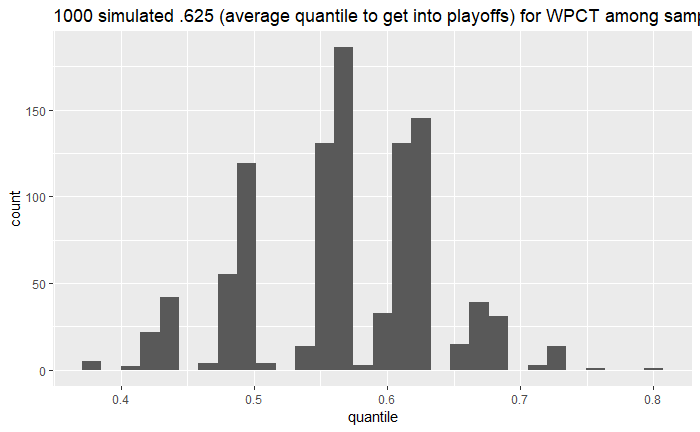

```r
SimsSmallN %>%
  ggplot() +
  geom_histogram(aes(x = quantile)) +
  ggtitle("1000 simulated .625 (average quantile to get into playoffs) for WPCT among samples of n = 15")
```

While we don’t have happiness data for each year, I decided to expand the data by including data that goes back to 2000 for the NFL teams, to give us a larger data set. We will now select 40 teams instead of 15.

```r
nBigger <- 40
SimsBigN <-
  mosaic::do(1000) * qdata(~ Win_Percent, p = 0.625,
                          data = sample_n(NFLHappiness, size = nBigger, replace = TRUE))
# inspect result
head(SimsSmallN)
```

|  | p | quantile |
| --- | --- | --- |
| 1 | 0.625 | 0.609375 |
| 2 | 0.625 | 0.609375 |
| 3 | 0.625 | 0.421875 |
| 4 | 0.625 | 0.484375 |
| 5 | 0.625 | 0.437500 |
| 6 | 0.625 | 0.562500 |

Next, I decided to construct a bootstrapped confidence interval

```r
NFLHappinessLargerData <-
  NFLHappiness %>%
  sample_n(size = 40, replace = FALSE)
# bootstrap distribution
BootStrapTrials <-
  mosaic::do(1000) * qdata(~ Win_Percent, p = 0.625,
                           data = sample_n(NFLHappiness, size = 40, replace = TRUE))
```

Our bootstrapped data seemed to appear mostly normal. This means we can use it a lot easier for further analysis

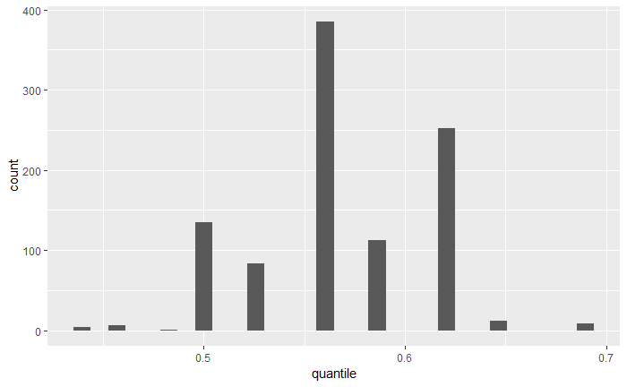

```r
BootStrapTrials %>%
  ggplot() +
  geom_histogram(aes(x = quantile))
```

To be 80% sure you’ll finish in the playoffs (62.5%), you need to finish with a .625 winning percentage - this shows our mean is completely on point.

```r
qdata(~ quantile, p = 0.8, data = BootStrapTrials)
```

```
       p quantile
   0.800    0.625
```

Then, changing paths slightly, we tried to apply a linear model to happiness and winning percentage. We just used the data from 2018 as our data set. The data gives us a almost horizontal line at .544. This shows that initially it is guessing there is almost no correlation between the two. We had hoped to maybe correlate happiness to playoff aspirations, but as there is not a strong relationship between happiness and winning percentage, we don’t think that relationship actually exists.

```r
sim1_lm <- lm(Win_Percent ~ Total_Score, data = NFLHappiness2)
sim1_lm$coefficients
```

```
  (Intercept)   Total_Score
 0.5440948073 -0.0008482548
```

```r
confint(lm(Win_Percent ~ 1, data = NFLHappiness2))
```

```
                2.5 %    97.5 %
(Intercept) 0.4308509 0.5613366
```

This is telling us it thinks the intercept is between .067 and 1.02. Then, the slope of the line could be between -.009498 and .0078

```r
confint(sim1_lm, level = 0.95)
```

```
                   2.5 %      97.5 %
(Intercept)  0.067927860 1.020261754
Total_Score -0.009498699 0.007802189
```

```r
msummary(sim1_lm)
```

```
              Estimate Std. Error t value Pr(>|t|)
(Intercept)  0.5440948  0.2324572   2.341   0.0266 *
Total_Score -0.0008483  0.0042230  -0.201   0.8423

Residual standard error: 0.1885 on 28 degrees of freedom
  (2 observations deleted due to missingness)
Multiple R-squared:  0.001439,  Adjusted R-squared:  -0.03422
F-statistic: 0.04035 on 1 and 28 DF,  p-value: 0.8423
```

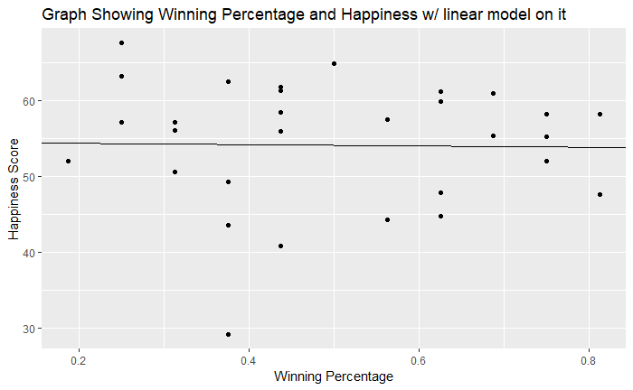

```r
NFLHappiness2 %>%
  ggplot(aes(x = Win_Percent, y = Total_Score)) +
  ggtitle("Graph Showing Winning Percentage and Happiness w/ linear model on it") +
  xlab("Winning Percentage") +
  ylab("Happiness Score") +
  geom_point() +
  geom_abline(slope = -00.8483, intercept = 54.440948)
```

Then, as the happiness seemed to be unrelated from winning percentage, we built a simulation to estimate if a NFL team will make the playoffs. This assumes each team has a random chance each year to make playoffs. For this one, we did a uniform distribution, ran it 10,000 times, and calculated the times it was above .625 (a 10-6 record - almost always enough to get a team into playoffs).

```r
n <- 10000
sim_meet <- data.frame(
  you <- runif(n, min = 0, max = 1)) %>%
  mutate(result = ifelse(you >= .625,
                         "You Made the Playoffs!", "Guess it was a rebuildling year"))
tally(~ result, format = "percent", data = sim_meet)
```

```
result
Guess it was a rebuildling year          You Made the Playoffs!
                           63.4                            36.6
```

Then, we created another simulation, changing the number of simulations we ran. This shows that as we took more and more trials, the data got more and more normal, which logically makes sense.

The following shows a normally distributed graph of proportion of times you make playoffs. From 100-400-1600 simulations, the data gets much more normally distributed. The mean stays approximately the same, but the variance decreases signficantly. This stands with the information learned in STAT 414.

```r
simple_sim <- function(num_sim = 1000, wait = .625) {
  you <- runif(num_sim, min = 0, max = 1)
  return(sum(you >= wait) / num_sim)
}
reps <- 25
params <- data.frame(num_sims = c(100, 400, 1600))
sim_results <-
  params %>%
  group_by(num_sims) %>%
  dplyr::do(mosaic::do(reps) * simple_sim(num_sim = .$num_sims, wait = .625))
sim_results
```

| num_sims | simple_sim |
| --- | --- |
| 100 | 0.380000 |
| 100 | 0.490000 |
| 100 | 0.470000 |
| 100 | 0.410000 |
| 100 | 0.490000 |
| 100 | 0.420000 |
| 100 | 0.420000 |
| 100 | 0.410000 |
| 100 | 0.410000 |
| 100 | 0.340000 |

[output cut: 65 more lines]

```r
favstats(simple_sim ~ num_sims, data = sim_results)
```

| num_sims | min | Q1 | median | Q3 | max | mean | sd | n | missing |
| --- | --- | --- | --- | --- | --- | --- | --- | --- | --- |
| 100 | 0.31000 | 0.370000 | 0.4000 | 0.420000 | 0.4900 | 0.398400 | 0.04784349 | 25 | 0 |
| 400 | 0.32250 | 0.355000 | 0.3725 | 0.380000 | 0.4025 | 0.369100 | 0.02066448 | 25 | 0 |
| 1600 | 0.34875 | 0.370625 | 0.3775 | 0.383125 | 0.3950 | 0.375975 | 0.01236000 | 25 | 0 |

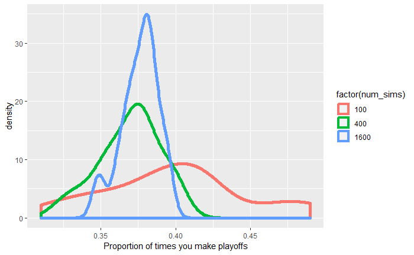

```r
sim_results %>%
  ggplot(aes(x = simple_sim, color = factor(num_sims))) +
  geom_density(size = 2) +
  scale_x_continuous("Proportion of times you make playoffs")
```

Next, I estimated the same data, except instead of a uniform distribution, I used a normal distribution. I found the mean and standard deviation of the overall data, and used it in my simulations.

```r
sd(NFLHappiness$Win_Percent)
```

```
[1] 0.1924932
```

```r
mean(NFLHappiness$Win_Percent)
```

```
[1] 0.4990718
```

```r
mean(HappyCities$Total_Score)
```

```
[1] 56.10956
```

```r
sd(HappyCities$Total_Score)
```

```
[1] 8.052058
```

Then, we ran a simulation, trying to find when a city was happy and had a playoff team. We assumed a normal distribution for simulation’s sake and wanted to find out when a city was happy and had a strong NFL team.

```r
n <- 100000
sim_meetExp <- data.frame(
  you <- rnorm(n, 0.4990718, .1924932),
  happycity <- rnorm(n, 56.10956, 8.052058)) %>%
  mutate(result = ifelse(test = (you >= .625 & happycity >= 56.109),
                         yes = "Good Times", no = "Something's Wrong"))
tally(~ result, format = "percent", data = sim_meetExp)
```

```
result
       Good Times Something's Wrong
           12.706            87.294
```

The following shows the combinatino of having a happy city and a strong NFL team. The shape of the graph makes sense, as it is two normally distributed graph on top of each other. We can see the one side of Happiness (above the mean) is selected, while the sampled winning percentage is above .625. This shows that it is fairly rare to have a good NFL team and a happy city - so enjoy it while you can if you’re lucky enough to live in the respective cities!

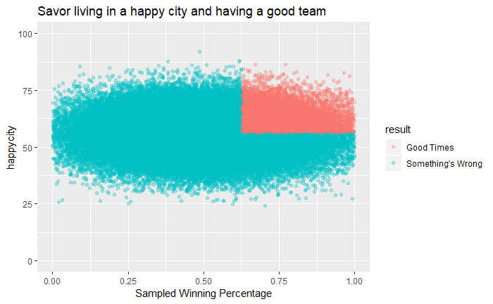

```r
sim_meetExp %>%
  ggplot() +
  geom_point(aes(x = you, y = happycity, color = result), alpha = 0.3) +
  xlab("Sampled Winning Percentage") +
  ggtitle("Savor living in a happy city and having a good team") +
  scale_x_continuous(limits = c(0, 1)) +
  scale_y_continuous(limits = c(0, 100))
```

Then, changing paths slightly, we started analyzing winning percentage and economic status. We added the economic data to the PlusHappy table from before.

```r
EconomyAndStats <- PlusHappy %>%
left_join(USACitiesEconomy, by = c("City" = "City_Name", "year" = "Year"))
head(EconomyAndStats)
```

|  | Teams | year | WPCT.x | league | City | Win_Percent | League.x | WPCT.y | League.y | WPCT | League | Population | Total_Score | Emotional_Physical_WellBeing_Rank | Income_Employment_rank | Community_Environment_Rank | Year | WPCT_x | WPCT_y | Total_WinPercent | Country_Code | GDP |
| --- | --- | --- | --- | --- | --- | --- | --- | --- | --- | --- | --- | --- | --- | --- | --- | --- | --- | --- | --- | --- | --- | --- |
| 1 | Phoenix | 2018 | 0.503 | MLB | Phoenix | 0.1875 | NFL | 0.232 | NBA | 0.4268293 | NHL | NA | 51.94 | 87 | 136 | 172 | 2018 | 0.503 | 0.232 | 0.3373323 | NA | NA |
| 2 | Atlanta | 2018 | 0.552 | MLB | Atlanta | 0.4375 | NFL | 0.354 | NBA | NA | NA | NA | 58.46 | 64 | 88 | 100 | 2018 | 0.552 | 0.354 | 0.4478333 | NA | NA |
| 3 | Baltimore | 2018 | 0.288 | MLB | Baltimore | 0.6250 | NFL | NA | NA | NA | NA | NA | 44.75 | 148 | 161 | 177 | 2018 | 0.288 | NA | 0.4565000 | NA | NA |
| 4 | Boston | 2018 | 0.663 | MLB | Boston | 0.6875 | NFL | 0.598 | NBA | 0.6829268 | NHL | NA | 60.96 | 34 | 12 | 152 | 2018 | 0.663 | 0.598 | 0.6578567 | NA | NA |
| 5 | Chicago | 2018 | 0.583 | MLB | Chicago | 0.7500 | NFL | 0.268 | NBA | 0.4634146 | NHL | NA | 55.20 | 60 | 175 | 114 | 2018 | 0.583 | 0.268 | 0.5161037 | NA | NA |
| 6 | Chicago | 2018 | 0.380 | MLB | Chicago | 0.7500 | NFL | 0.268 | NBA | 0.4634146 | NHL | NA | 55.20 | 60 | 175 | 114 | 2018 | 0.380 | 0.268 | 0.4653536 | NA | NA |

The graph appears to be normally distributed. It shows winning percentage against GDP in each city. While there are a few outliers, these points have a smaller GDP. It seems that the data does follow a normal distribution, as there is more GDP when the teams are closer to .500 winning percentage, although it also has more lower ones too along with higher ones.

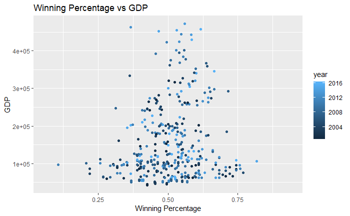

```r
EconomyAndStats <-
EconomyAndStats %>%
filter(year < 2017) %>%
filter(year > 2000)
EconomyAndStats %>%
ggplot(aes(x = Total_WinPercent, y = GDP, color = year)) +
geom_point() +
  ggtitle("Winning Percentage vs GDP") +
  xlab("Winning Percentage") +
  ylab("GDP")
```

The next graph shows the 2015 data with city labels put on it. It mostly backs up our findings from last time, as teams with the largest GDP were around 500, mainly being Boston, Houston, and Dallas. There were a few extreme outliers, such as San Antonio. However, this makes sense as it only has one team, indicating its smaller size as a city. The Spurs happen to be good now, so they’ll have a high winning percentage, and not have any other teams to balance it out.

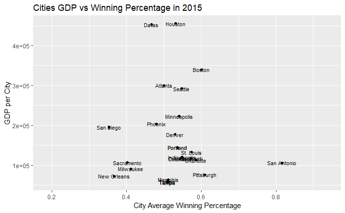

```r
EconomyAndStats %>%
  filter(year == 2015) %>%
  ggplot(aes(x = Total_WinPercent, y = GDP)) +
  ggtitle("Cities GDP vs Winning Percentage in 2015") +
  xlab("City Average Winning Percentage") +
  ylab("GDP per City") +
  geom_point() +
  geom_text(aes(label = City), size = 3)
```

```r
EconomyAndStats2 <-
EconomyAndStats %>%
filter(year == 2015)
EAS_std <-
EconomyAndStats2 %>%
mutate(ScaledWPCT = scale(EconomyAndStats2$Total_WinPercent)) %>%
as.data.frame()
EAS_std
```

| Teams | year | WPCT.x | league | City | Win_Percent | League.x | WPCT.y | League.y | WPCT | League | Population | Total_Score | Emotional_Physical_WellBeing_Rank | Income_Employment_rank | Community_Environment_Rank | Year | WPCT_x | WPCT_y | Total_WinPercent | Country_Code | GDP | ScaledWPCT |
| --- | --- | --- | --- | --- | --- | --- | --- | --- | --- | --- | --- | --- | --- | --- | --- | --- | --- | --- | --- | --- | --- | --- |
| Phoenix | 2015 | 0.488 | MLB | Phoenix | 0.8125 | NFL | 0.280 | NBA | 0.3414634 | NHL | 4558145 | 51.94 | 87 | 136 | 172 | 2018 | 0.488 | 0.280 | 0.4804909 | USA12 | 203864 | -0.36181955 |
| Atlanta | 2015 | 0.414 | MLB | Atlanta | 0.5000 | NFL | 0.585 | NBA | NA | NA | 5364566 | 58.46 | 64 | 88 | 100 | 2018 | 0.414 | 0.585 | 0.4996667 | USA10 | 300121 | -0.17249332 |
| Baltimore | 2015 | 0.500 | MLB | Baltimore | 0.3125 | NFL | NA | NA | NA | NA | NA | 44.75 | 148 | 161 | 177 | 2018 | 0.500 | NA | 0.4062500 | NA | NA | -1.09481262 |
| Boston | 2015 | 0.481 | MLB | Boston | 0.7500 | NFL | 0.585 | NBA | 0.5853659 | NHL | 4347346 | 60.96 | 34 | 12 | 152 | 2018 | 0.481 | 0.585 | 0.6003415 | USA11 | 339890 | 0.82148691 |
| Chicago | 2015 | 0.599 | MLB | Chicago | 0.3750 | NFL | 0.512 | NBA | 0.6219512 | NHL | NA | 55.20 | 60 | 175 | 114 | 2018 | 0.599 | 0.512 | 0.5269878 | NA | NA | 0.09725308 |
| Chicago | 2015 | 0.469 | MLB | Chicago | 0.3750 | NFL | 0.512 | NBA | 0.6219512 | NHL | NA | 55.20 | 60 | 175 | 114 | 2018 | 0.469 | 0.512 | 0.4944878 | NA | NA | -0.22362518 |
| Cincinnati | 2015 | 0.395 | MLB | Cincinnati | 0.7500 | NFL | NA | NA | NA | NA | 2104771 | 43.50 | 165 | 145 | 162 | 2018 | 0.395 | NA | 0.5725000 | USA21 | 117392 | 0.54660309 |
| Cleveland | 2015 | 0.500 | MLB | Cleveland | 0.1875 | NFL | 0.695 | NBA | NA | NA | NA | 40.81 | 163 | 180 | 164 | 2018 | 0.500 | 0.695 | 0.4608333 | NA | NA | -0.55590170 |
| Denver | 2015 | 0.420 | MLB | Denver | 0.7500 | NFL | 0.402 | NBA | 0.5487805 | NHL | 2807211 | 62.41 | 21 | 64 | 116 | 2018 | 0.420 | 0.402 | 0.5301951 | USA18 | 177116 | 0.12891956 |
| Detroit | 2015 | 0.457 | MLB | Detroit | 0.4375 | NFL | 0.537 | NBA | 0.6097561 | NHL | 4363301 | 29.19 | 181 | 181 | 181 | 2018 | 0.457 | 0.537 | 0.5103140 | NA | NA | -0.06737006 |

[output cut: 74 more lines]

```r
favstats(~ `ScaledWPCT`, data = EAS_std)
```

|  | min | Q1 | median | Q3 | max | mean | sd | n | missing |
| --- | --- | --- | --- | --- | --- | --- | --- | --- | --- |
|  | -3.25457 | -0.5023568 | -0.05904709 | 0.4911116 | 4.150313 | -4.411451e-16 | 1 | 84 | 0 |

```r
EAS_dist <- dist(EAS_std)
```

```
NAs introduced by coercion
```

```r
EAS_dendo <-
EAS_dist %>%
hclust(method = "complete")
print(EAS_dendo)
```

```
Call:
hclust(d = ., method = "complete")

Cluster method   : complete
Distance         : euclidean
Number of objects: 84
```

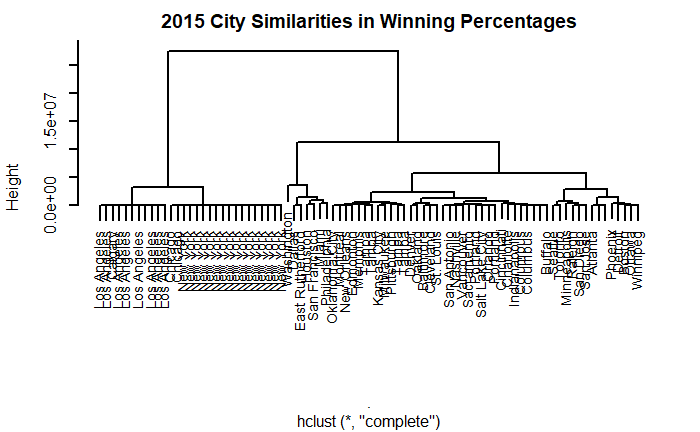

```r
EAS_dendo %>%
plot(cex = 0.9, labels = EconomyAndStats2$City, lwd = 2,
main = "2015 City Similarities in Winning Percentages")
```

## Conclusion

In conclusion, we had hoped to find a relation between sports team’s successes and failures to how a city operates both economically and emotionally. We found that there is no significant relation.

One can come up with the idea that as people who don’t live in these cities, we only know what they are like through sports. As Philadelphia teams struggled in the past years, there was not really a change in the the mood of the city for the entire year. If we broke down the city data to a smaller scale, as teams host championship games or compete in big games, there may be an actual relation.

If we were to look further into this, we would hope to see weekly or monthly data. When looking at city’s statistics, by making it so huge time periods, we see minimal changes, but drastic changes in the sports success force there to be no correlation.

As big as sports teams may feel to a city, they are nothing compared to the size of the cities they represent. There is too much going on for a few extra happy people to actually change statistics of the whole city, enough to force a trend to be apparent. This was seen best in the simulation, as the graphs appear to be independent between happiness and winning percentage. This was really seen when the linear model produced a straight line. Along with this, we also saw there wasn’t a large difference between economic data and winning percentage, instead that made more of a normal curve. We suspected this was because the big cities, with a large GDP had many sports teams to balance their winning percentages out, with a few smaller teams, who were particularly bad and good. This once again showed that winning percentage probably wasn’t tied to GDP changes. Finally, we also saw that city sizes frequently caused their winning percentages to be grouped together. Overall, we were disappointed to not find many correlations, but we reported our findings fully and accurately and did not attempt to spin and taper with the results to support our original thoughts.